# MAE5776 - 1º Sem/2022

# Análise Descritiva Multivariada

**Alunos:**

Fernando F. Paulos Vieira - nº USP: 13492870

Leandro Alves da Silva - nº USP: 11868023

Thiago Ferreira Miranda - nº USP: 11925711

Considere os dados “Iris” (Fisher, RA, 1936. The use of multiple measurements in taxonomic problems. Annals of Eugenics 7, Part II: 179–188), com medidas do comprimento e largura da pétala e da sépala de 150 flores de íris, sendo 50 observações de cada uma das espécies setosa, versicolor e virginica.

**1. Discuta a estrutura destes dados:** variáveis resposta (quantas? quantitativas?), possíveis fatores sob estudo, tamanho amostral. Que objetivos poderiam ser de interesse no estudo?

**R:**

O banco de dados apresenta 1 variável resposta categórica, denominada Species e, 4 variáveis quantitativas (Petal.Length, Sepal.Length, Petal. Width, Sepal. Width).

Como possíveis fatores sob estudo temos as dimensões observadas de cada uma das variáveis quantitativas, características especificas por espécie e/ou tendências, bem como nível de dependência apresentadas por determinada variável (a depender ou não da espécie). Isso ao considerar um tamanho amostral de 165 observações.

Candidatados a objetivos de interesse no estudo poderíamos citar:

- Identificar quais espécie apresentam maiores e menores dimensionais;
- Verificar se existe correlação entre as dimensões de pétala e sépala de uma mesma espécie ou independente da espécie;
- Identificar o grau de pureza dos clusters, ou seja, se os grupos possuem “limites” com separações claras e bem definidas;
- E, quais variáveis possuem maior e menor variabilidade e se há diferença na análise das observações totais ou por grupo (espécie)

**2.** Usando os recursos do R realize a **análise descritiva multivariada** desses dados:

Neste relatório utilizaremos a base iris com os dados incrementais, onde foram simuladas 15 novas observações, 5 para cada espécie de flor. Como incremento, levamos em conta o vetor de médias e a matriz de covariância das 150 observações originais.

```r
iris_num <- iris %>%
  select(Petal.Length,Sepal.Length,Petal.Width,Sepal.Width)

iris_mean <- colMeans(iris_num)
iris_cov <- cov(iris_num)

set.seed(123)
novas_observacoes <- MASS::mvrnorm(15,iris_mean,iris_cov)
novas_observacoes <- novas_observacoes %>%
  data.frame(Species = c(rep("setosa",5),rep("versicolor",5),rep("virginica",5)))
```

| Petal.Length | Sepal.Length | Petal.Width | Sepal.Width | Species |
| --- | --- | --- | --- | --- |
| 2.543975 | 5.990097 | 0.9157430 | 3.813350 | setosa |
| 3.273876 | 5.900967 | 1.0130766 | 3.207184 | setosa |
| 6.656210 | 6.242556 | 2.6117551 | 2.205698 | setosa |
| 3.898806 | 5.941656 | 1.2684931 | 3.482683 | setosa |
| 4.037466 | 5.656817 | 1.4472768 | 2.998068 | setosa |
| 6.903811 | 6.648000 | 2.5782377 | 2.502821 | versicolor |
| 4.598236 | 6.026570 | 1.6348887 | 2.990035 | versicolor |
| 1.612669 | 4.583564 | 0.3010011 | 2.895691 | versicolor |
| 2.705193 | 5.080312 | 0.5144576 | 2.930929 | versicolor |
| 3.001492 | 5.382918 | 0.8624294 | 2.835206 | versicolor |
| 6.155859 | 6.246619 | 1.8813859 | 2.196592 | virginica |
| 4.201111 | 6.490971 | 1.5817367 | 3.184926 | virginica |
| 4.467208 | 6.368252 | 1.2277131 | 2.860114 | virginica |
| 4.105594 | 5.198382 | 1.6398708 | 2.997509 | virginica |
| 2.713528 | 5.628687 | 0.9024688 | 3.817567 | virginica |

**Vetor de Médias (Centróide)** para a amostra total e por grupo.

|  | Total (n=165) | G1 Setosa (n=55) | G2 Versicolor (n=55) | G3 Virginica (n=55) |
| --- | --- | --- | --- | --- |
| Petal.Length Y1 | 3.785303 | 1.7001879 | 4.214935 | 5.440787 |
| Sepal.Length Y2 | 5.841736 | 5.0914926 | 5.900388 | 6.533326 |
| Petal.Width Y3 | 1.213821 | 0.3555699 | 1.312564 | 1.973331 |
| Sepal.Width Y4 | 3.051626 | 3.4019451 | 2.775540 | 2.977395 |

Qual variável tem maior e menor média?

**R:**

A variável Sepal.Length possui a maior média (ao considerarmos a amostra total e por grupo). E a variável Petal.Width possui a menor média (ao considerarmos a amostra total e por grupo).

Qual flor de íris (espécie) parece ser maior que as demais?

**R:**

A espécie virginica parece ser maior, pois apresenta (na maior parte dos casos) maiores valores médios das dimensões observadas nas amostras por grupo, tendo em vista as 4 variáveis quantitativas avaliadas.

**Matriz de Covariância e Correlação:** $S_{T}$ (triangular superior) e $R_{T}$ (triangular inferior)

| $R_{T} \| S_{T}$ | Y1 | Y2 | Y3 | Y4 |
| --- | --- | --- | --- | --- |
| Y1 | 3.0424040 | 1.2131628 | 1.2651379 | -0.3452652 |
| Y2 | 0.8619669 | 0.6510885 | 0.4921719 | -0.0429298 |
| Y3 | 0.9627368 | 0.8096082 | 0.5676018 | -0.1269775 |
| Y4 | -0.4510417 | -0.1212302 | -0.3840407 | 0.1925996 |

Calcule a variância total e a variância generalizada:

**tr(S) =** 4.4536939 **|S| =** 0.0017801

**tr(R) =** 4 **|R| =** 0.0082203

Qual variável tem maior variabilidade? E qual tem a menor variabilidade?

**R:**

A variável Petal.Length(Y1) tem a maior variabilidade, enquanto a variável Sepal.Width(Y4) tem a menor variabilidade.

**3.** Quais variáveis estão mais correlacionadas?

Para o total das observações, independente da espécie, as variáveis Petal.Length(Y1) e Petal.Width(Y3) estão mais correlacionadas que as demais, com coeficiente de correlação de 0.96.

**Análise por espécie:**

| Setosa $S_{1}$ | Y1 | Y2 | Y3 | Y4 |
| --- | --- | --- | --- | --- |
| Y1 | 0.7844795 | 0.2360529 | 0.3490775 | -0.1183619 |
| Y2 | 0.6107180 | 0.1904390 | 0.1111203 | 0.0634375 |
| Y3 | 0.9650657 | 0.6235068 | 0.1667817 | -0.0490908 |
| Y4 | -0.3294949 | 0.3584226 | -0.2963832 | 0.1644921 |

**tr(S) =** 1.3061922 **|S| =** 0.0000671

**tr(R) =** 4 **|R| =** 0.0163641

| Versicolor $S_{2}$ | Y1 | Y2 | Y3 | Y4 |
| --- | --- | --- | --- | --- |
| Y1 | 0.5337420 | 0.3035851 | 0.2133808 | 0.0512363 |
| Y2 | 0.7547736 | 0.3031071 | 0.1104355 | 0.0679776 |
| Y3 | 0.9156849 | 0.6288790 | 0.1017390 | 0.0271635 |
| Y4 | 0.2307277 | 0.4062142 | 0.2801746 | 0.0923900 |

**tr(S) =** 1.0309781 **|S| =** 0.0000751

**tr(R) =** 4 **|R| =** 0.0494032

| Virginica $S_{3}$ | Y1 | Y2 | Y3 | Y4 |
| --- | --- | --- | --- | --- |
| Y1 | 0.5140718 | 0.3596855 | 0.1332712 | 0.0085015 |
| Y2 | 0.7741842 | 0.4198880 | 0.0764723 | 0.0746787 |
| Y3 | 0.5666453 | 0.3597695 | 0.1076035 | 0.0277114 |
| Y4 | 0.0342564 | 0.3329582 | 0.2440645 | 0.1198064 |

**tr(S) =** 1.1613698 **|S| =** 0.0004748

**tr(R) =** 4 **|R| =** 0.1706206

**Matrizes de Distância**

Considere as 6 primeiras flores:

Apresente a Matriz de Distâncias Euclidiana (n=6):

|  | X1 | X2 | X3 | X4 | X5 | X6 |
| --- | --- | --- | --- | --- | --- | --- |
| X1 | 0.0000000 | 0.5385165 | 0.509902 | 0.6480741 | 0.1414214 | 0.6164414 |
| X2 | 0.5385165 | 0.0000000 | 0.300000 | 0.3316625 | 0.6082763 | 1.0908712 |
| X3 | 0.5099020 | 0.3000000 | 0.000000 | 0.2449490 | 0.5099020 | 1.0862780 |
| X4 | 0.6480741 | 0.3316625 | 0.244949 | 0.0000000 | 0.6480741 | 1.1661904 |
| X5 | 0.1414214 | 0.6082763 | 0.509902 | 0.6480741 | 0.0000000 | 0.6164414 |
| X6 | 0.6164414 | 1.0908712 | 1.086278 | 1.1661904 | 0.6164414 | 0.0000000 |

Apresente a Matriz de Distâncias de Pearson (Euclidiana Padronizada) (n=6):

|  | X1 | X2 | X3 | X4 | X5 | X6 |
| --- | --- | --- | --- | --- | --- | --- |
| X1 | 0.0000000 | 1.1659610 | 0.8463568 | 1.1036295 | 0.2593840 | 1.0339356 |
| X2 | 1.1659610 | 0.0000000 | 0.5219264 | 0.4398160 | 1.3727787 | 2.1655581 |
| X3 | 0.8463568 | 0.5219264 | 0.0000000 | 0.2835976 | 0.9860303 | 1.8492662 |
| X4 | 1.1036295 | 0.4398160 | 0.2835976 | 0.0000000 | 1.2438081 | 2.0951239 |
| X5 | 0.2593840 | 1.3727787 | 0.9860303 | 1.2438081 | 0.0000000 | 0.9017132 |
| X6 | 1.0339356 | 2.1655581 | 1.8492662 | 2.0951239 | 0.9017132 | 0.0000000 |

|  | Dist. Euclidiana | Dist. Pearson |
| --- | --- | --- |
| Quais flores são mais parecidas? | X1 e X5 (0.1414214) | X1 e X5 (0.2593840) |
| Quais flores são mais diferentes? | X4 e X6 (1.1661904) | X2 e X6 (2.1655581) |

**4.** Há observações atípicas? Considere a análise independente de espécie. Outlier univariado: construa o boxplot para cada variável

**R:**

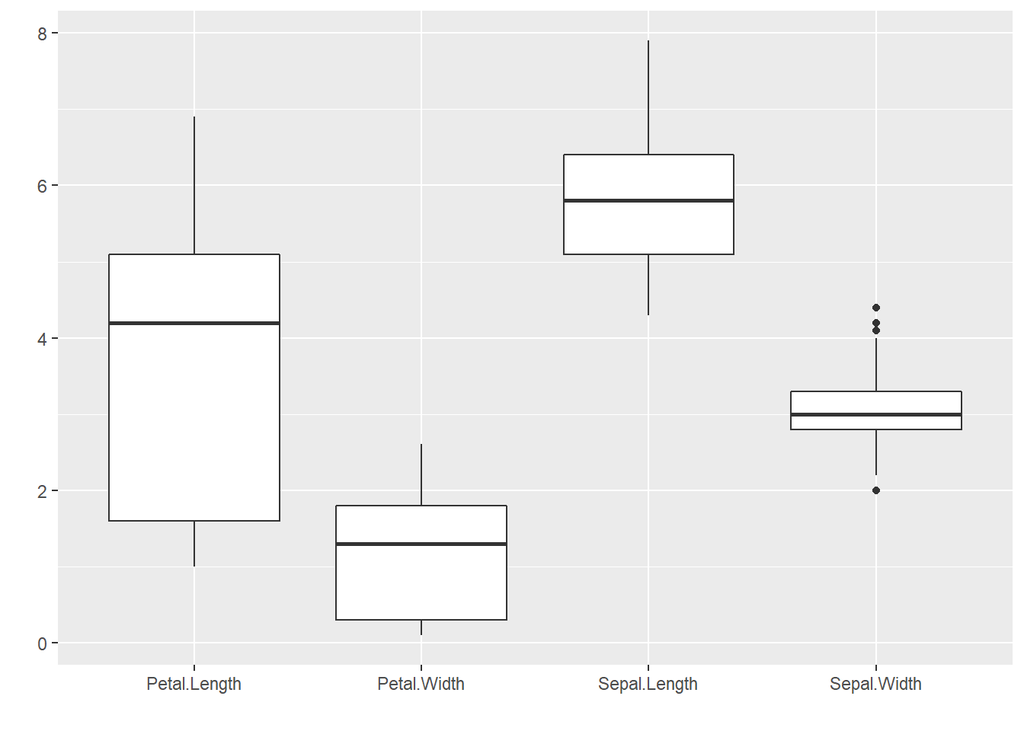

Sim, há observações atípicas, pois pode-se observar que o boxplot da variável Sepal.Width apresenta 4 outliers (sendo estes as observações 16, 33, 34 e 61).

Outilier Bivariado: Construir o Bivbox (considere pares de variáveis)

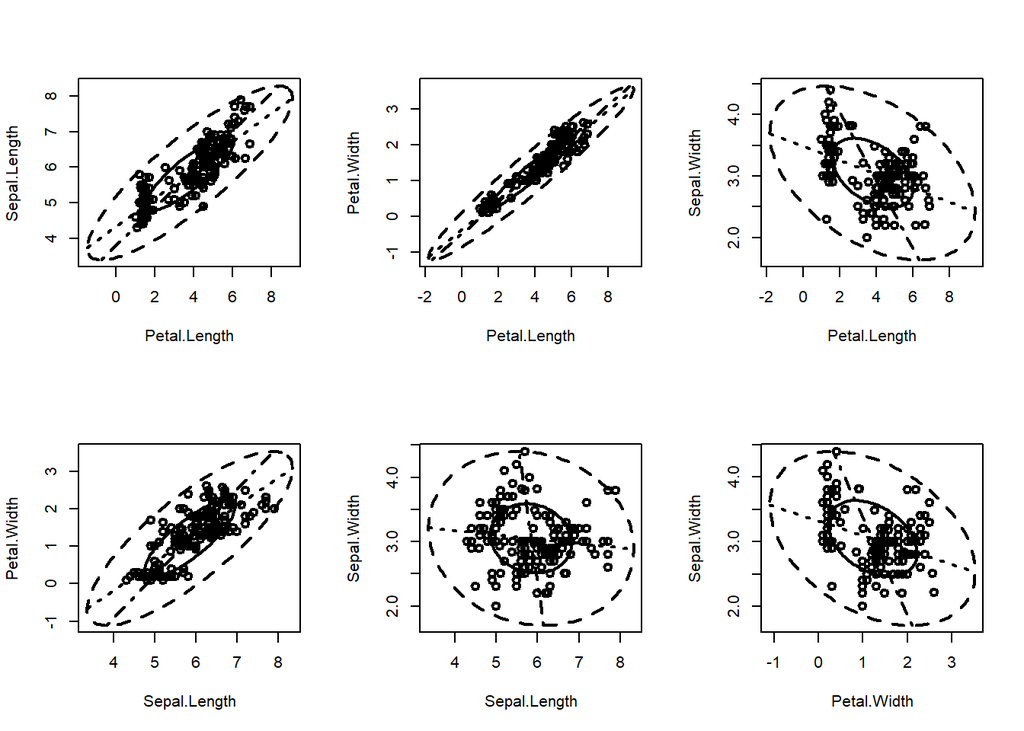

Outliers Multivariados (p=4): Obtenha o gráfico com a distância de Mahalanobis das observações ao centróide. A padronização dos dados influencia a análise de observações atípicas?

**R:**

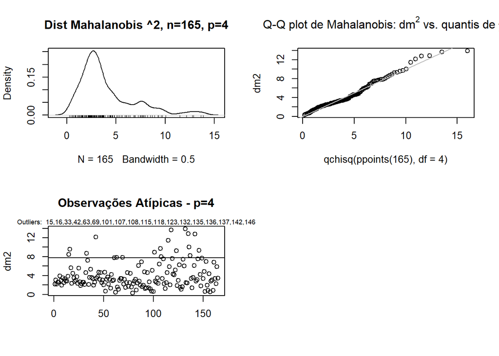

A padronização dos dados (utilizando os critérios para obtenção da distância de Mahalanobis) influencia a análise de observações atípicas, anteriormente ao avaliar somente com o critério do boxplot de modo univariado foram sinalizadas 4 observações atípicas, no entanto ao considerar uma análise multivariada (por meio dos critérios da distância de Mahalanobis) agora temos 18 observações atípicas evidenciadas.